# STOR 455 Class 36 R Notebook

```r
library(readr)

Exams4 <- read_csv("https://raw.githubusercontent.com/JA-McLean/STOR455/master/data/Exams4.csv")
Diet <- read_csv("https://raw.githubusercontent.com/JA-McLean/STOR455/master/data/Diet.csv")
Glue <- read_csv("https://raw.githubusercontent.com/JA-McLean/STOR455/master/data/Glue.csv")
```

*Diet Information* - Investigate the data to determine the impact of the type of diet and Sex on mean weight loss in separate models. - Evaluate the residuals for the appropriateness of using the ANOVA model in each model - Use pairwise methods to investigate differences between means if the overall ANOVA model is significant.

**Goal:** - Want to see the impact of each diet and how the diet and sex effects teh mean weight loss - First model: ANOVA MOdel by WEight loss by Sex - SEcond: Anova by WEight loss by Diet type

- Want to look at residual plot to check the conditions and if we do see there are sig differences by sex or diet, then we want to follow up and do a pairwise comparision like we did last time to see where those differences are.

```r
head(Diet)
```

| Person | Sex | Age | Height | Preweight | Diet | weight6weeks |
| --- | --- | --- | --- | --- | --- | --- |
| 25 | NA | 41 | 171 | 60 | 2 | 60.0 |
| 26 | NA | 32 | 174 | 103 | 2 | 103.0 |
| 1 | 0 | 22 | 159 | 58 | 1 | 54.2 |
| 2 | 0 | 46 | 192 | 60 | 1 | 54.0 |
| 3 | 0 | 55 | 170 | 64 | 1 | 63.3 |
| 4 | 0 | 33 | 171 | 64 | 1 | 61.1 |

There is no weight change variable so we will need to make a variable called weight change and subtract teh differences in weight begining and afterwards.

- Then look back, make an anova model for weight change by diet and then follow through the process of checking the conditions and see wehre teh sig difference with teh pairwise analysis if tehy exists
- Repeat for Sex
- Then we will talk about how to do one test that does the two things above twice

**THE DIET INFORMATION IS NOT ALREADY WRITTEN IN THE RMARKDOWN FILE, YOU WILL NEED TO WRITE THIS FROM THE SLIDE** *Diet Data Conclusions* **Question1:** Are there dif in weight change depending on the diet you are on and if there are, which diet(s) seem to be sig different than each other?

*There are changes* - **Best diet:** The 3rd one – They lost about on average 2kg more and there are sig dif – Practically this doesnt mean its better. Maybe it’s more miserable to be on than the others – Maybe it’s not worth it, but from a stats standpoint, there is a difference there

**Diet Code** - First: Make a new var of the dataframe = weight change - Second: Make a model and factor the diet because we want to see the 3 separate diets - Third: Look at teh summary of that

Ho: Mean weight change for each diet is equal Ha: At least one mean weight change for a diet is differnt

**To see where the differences are, look at the Tukey analysis** *Tukey’s* Gives us middle ground *Bonferroni* Increases chance of type 2 error, so we would need more evidence, which is why we don’t do that one. You can in the future if you ever need it though.

*Tukey’s output* - Inflated p-value: There are two places were the pvlaue is below a point 0.05 level and that’s wehre we are comparing diet 3:1 and 3:2; – Sig dif exist bt the mean weight change bt 3:1 and 3:2 –If you didn’t factor diet, Tukey would probably be mad at you and not run **Troubleshooting**

```r
TukeyHSD(weightchange_diet)
```

```
  Tukey multiple comparisons of means
    95% family-wise confidence level

Fit: aov(formula = weightchange ~ factor(Diet), data = Diet)

$`factor(Diet)`
          diff        lwr      upr     p adj
2-1 -0.2740741 -1.8806155 1.332467 0.9124737
3-1  1.8481481  0.2416067 3.454690 0.0201413
3-2  2.1222222  0.5636481 3.680796 0.0047819
```

**Additional Analysis for Sex** Not much is different; iot says two obs were delted, because there were 2 NA’s for sex that weren’t listed

Looking at teh summary: Sum of Squeares tells us little variability is explained by this model, but we have a high pvalue, so we don’t have evidence to say that Sex plays a role in the weight change

Ho: Sexes are all equal Ha: Sexes are not equal

**Looking at the plots: Does it fit the conditions?** - No need to do a Tukey follow up because we don’t see a difference between the groups, so there’s no reason to keep going with that.

*LAst two classes* We looked at the level combinations of the variables: ex: Student and grade; here there are more because sex and diet; many people of sex 1 on different diets, so there are more than 1 person in each categories.

**HOw to tell if it is a good model?** - Look at teh summary to get an idea of how much variably is explained by this model compared to the total variablity(vs what is not being explained by the model is a better way to put it)

```r
weightchange_Sex <- aov(weightchange~factor(Sex), data = Diet)
summary(weightchange_Sex)
```

```
            Df Sum Sq Mean Sq F value Pr(>F)
factor(Sex)  1    0.3   0.278   0.044  0.835
Residuals   74  470.7   6.360
2 observations deleted due to missingness
```

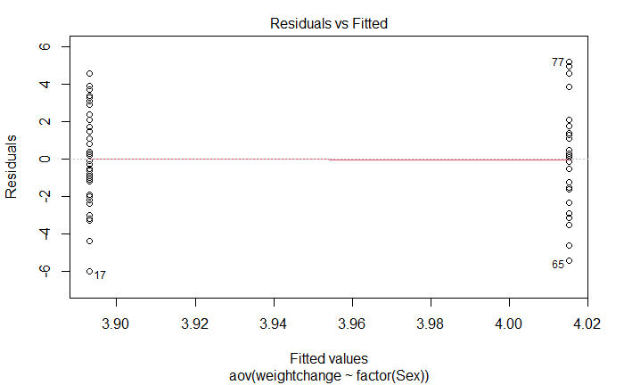

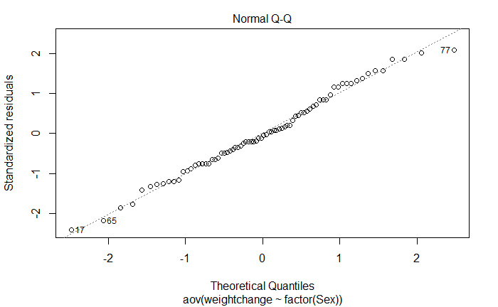

```r
plot(weightchange_Sex, 1:2)
```

**Example: Exam Score** *We want to build a model with both Sex and the Diet* - We want to compare what is explained vs not explained - If there ar emore variables, then tehre will be less unexplained because they will explain some of the the differences that we see - When we build a bigger model, what you’re comparing (the variabilaity that is explained by that predictor too) is going to change

*We’ve shown (one-way):* *No significant differences between the exams* *Significant differences between the students*

**Question:** Can we use BOTH factors to help explain the variability in the exam scores?

**Repeat the models from last time** amodC is a different test now

**Simple Block Design**

**Define**: A simple block design has two factors with exactly one data value in each combination of the factors.

Assume: Factor A (Treatments) has K levels Factor B (Blocks) has J levels  n= K∙J data values

- Putting both model wants into one is a simpl block design; where we take 2 factors (Student and Exam) and we see which one is treatmetn or block and teh blocks (how we split them up) and treatment (apply different treatments)
- Treatmetns = levels (exams, student names, etc)
- We have one value for each person in our data

*thinking about what the model is doing* - Still thinking about the overall average of what is going one - we want to see how the different effects are on the model; what are the effects of it being this particualr student or this block that we are in (which exam or which student) - leaves us with what the differences are for each combination of the different levels of our treatment and block

**Two-way ANOVA: Main Effects Model** Y = mu + alphak + Bj+ E Y = GrandMean + effect for kth treatment + effect for jth block + Random Error

**Randomize Block - Calculations** 1. Find the mean for each treatment (row means), each block (column means), and grand mean. 2. Partition the SSTotal into three pieces: – SSTotal = SSA + SSB + SSE

SSTotal = sum(y-ybar)^2 = (n-1)s^2 SSA = row means SSB = column means SSE = SSTotal - SSA-SSB

**Randomized Block ANOVA Table** **Format:** Row(Header): [1,2],[1,3],[1,4],etc. Source: d.f, S.S., M.S, t.s., P-value Facotr A: K-1, SSA, SSA/(K-1), MSA/MSE Factor B: J-1, SSb, SSB/(J-1), MSB/MSE Error: (K-1)(J-1), SSE, SSE/(K-1)(J-1), [4,4], [4,5] Total: n-1, SSTotal

**Testing Two hypotheses** Ho: alpha1 = alpha 2=…= alphaK=0 Ha: Some alpha k != 0 Factor A: Difference in treatment means? Above, we are assuming that the factor a has no effect on the factor b

Ho: B1 = B 2=…= BJ=0 Ha: Some B j != 0 Facotr B: Difference in block means? THis second test is looking at the factor b and seeing if it has no effect on factor a; - we just swapped the two things we are testing, so we test both of the variables

- We get different results because the residuals left over will be smaller because we are combining to see which is being explained by each of these things at once

**Looking at the summary of amodA, B, and C** - WHen individually, there are no sig dif by exam, - When put together, there are sig difference

*Reason:* If you look at teh SSResid in teh Exam model, that is big, but if you look in the other it’s smaller because the var is being explained by Student - It’s not really testing the same thing; one is in a vaccum and one is in the model, but we are saying that if we are jsut looking at the unaccounted varibaility, then there are sig differences on the average scores by exam in the population.

*Conclusion* Evidence of a difference in means between exams. and Evidence of a difference in means between students.

```r
amodA = aov(Grade~factor(Exam), data=Exams4)
summary(amodA) #This SSR Residuals is bigger because there is alot that is not being explained by the predictor
```

```
             Df Sum Sq Mean Sq F value Pr(>F)
factor(Exam)  3   1030   343.3   1.056  0.395
Residuals    16   5200   325.0
```

```r
amodB = aov(Grade~Student, data=Exams4)
summary(amodB) #This SSR Res id smaller bc when we look at mean by student, a lot of the variability is explained; when we predict Bub's score with the other average that he did, we know more where it is coming from
```

```
            Df Sum Sq Mean Sq F value   Pr(>F)
Student      4   4480  1120.0     9.6 0.000468 ***
Residuals   15   1750   116.7
---
Signif. codes:  0 ‘***’ 0.001 ‘**’ 0.01 ‘*’ 0.05 ‘.’ 0.1 ‘ ’ 1
```

```r
#amodC = combines amodA and amodB
amodC = aov(Grade~factor(Exam)+Student, data=Exams4)
summary(amodC)
```

```
             Df Sum Sq Mean Sq F value   Pr(>F)
factor(Exam)  3   1030   343.3   5.722   0.0114 *
Student       4   4480  1120.0  18.667 4.35e-05 ***
Residuals    12    720    60.0
---
Signif. codes:  0 ‘***’ 0.001 ‘**’ 0.01 ‘*’ 0.05 ‘.’ 0.1 ‘ ’ 1
```

**Following Up with Tukey** - This output is a series of the mult comparision with every poss comb of factor A and then every combo of factor B; - there are sig dif for each factor

*Looking at output by exam* Exam 2 and 1 have a low p value and 3 and 2 have a low p value; those are where we are saying *THERE IS SIG DIF IN THE POPULATION*; if its practical is another thing

*Looking at output by student* : simialr results,that bud has a lower average, bud and bob, bill, betsy and bard are all sig and none of the other values are because we don’t have a lot of added explained variability by having the exams

by adding the exam it didn;’t really show wehre to see diferences, but it worked the other way

```r
TukeyHSD(amodC)
```

```
  Tukey multiple comparisons of means
    95% family-wise confidence level

Fit: aov(formula = Grade ~ factor(Exam) + Student, data = Exams4)

$`factor(Exam)`
    diff         lwr        upr     p adj
2-1   15   0.4554143 29.5445857 0.0425678
3-1   -4 -18.5445857 10.5445857 0.8455825
4-1    1 -13.5445857 15.5445857 0.9968212
3-2  -19 -33.5445857 -4.4554143 0.0102092
4-2  -14 -28.5445857  0.5445857 0.0605331
4-3    5  -9.5445857 19.5445857 0.7409734

$Student
           diff        lwr        upr     p adj
Betsy-Barb   16  -1.458285  33.458285 0.0782719
Bill-Barb     4 -13.458285  21.458285 0.9451946
Bob-Barb      8  -9.458285  25.458285 0.6039841
Bud-Barb    -28 -45.458285 -10.541715 0.0019421
Bill-Betsy  -12 -29.458285   5.458285 0.2467758
Bob-Betsy    -8 -25.458285   9.458285 0.6039841
Bud-Betsy   -44 -61.458285 -26.541715 0.0000293
Bob-Bill      4 -13.458285  21.458285 0.9451946
Bud-Bill    -32 -49.458285 -14.541715 0.0006169
Bud-Bob     -36 -53.458285 -18.541715 0.0002093
```

**Same visual from last time** - When they cross zero: means we predict there could be no difference betweent eh things - When they don’t cross zero: Visual to see wehre the differnces are that there could be a difference between tehse things

**We have been doing two way because we haev two predictors** *What about the conditions?*

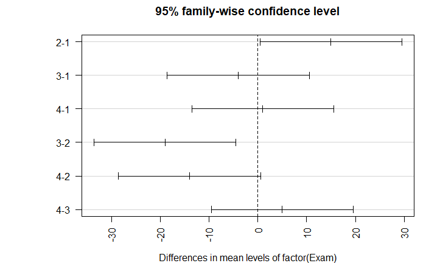

```r
par(mar=c(4,7,3,1))
hsd=TukeyHSD(amodC)
plot(hsd,las=2)
```

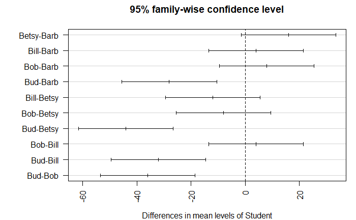

```r
par(mar=c(5,4,2,2))
```

*Looking at the conditions* - Constant variance: A little harder, but look at the fitted residuals, there are more columsn of data we haev to worry about here, overlal it looks good, but we can’t see much - NormalQQPlot of residuals : This is a small dataset, so nothing stands out as really bad.

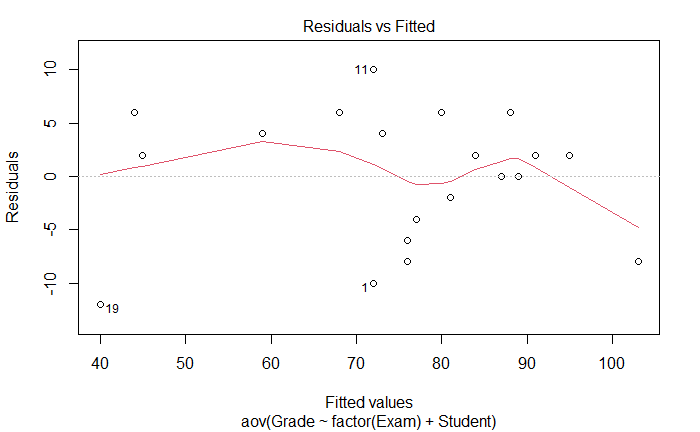

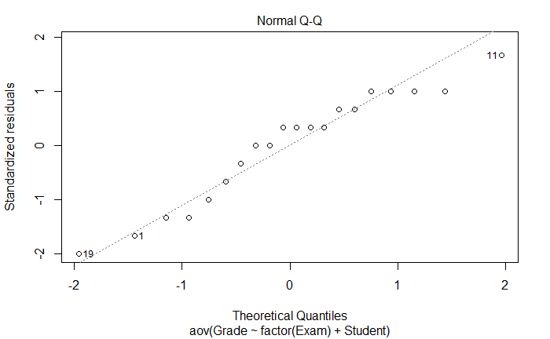

```r
plot(amodC, 1:2)
```

**Looking back at the diet data** - GO in with a two way anova model Ho: Mean weights by diets are equal and themean weight changes are equal Ha: At least one is difference

Ho: Mean weight change by sex are equal Ho: Mean weight change by weight are not equal by sex

*Check COnditions* - None of them look sus

**Still need to think about: THe idea of interaction now** - We are saying that the diets there are sig differences there from weight changes and there are no sig difference by sex for weight change, but could there be interactions. I nother owords, woudl some diets work for some sexes thant he others and are there difference there?

If we look at the dif of weight change by sex and diet, could we explain more variabiltiy that’s left unexplained here.

[figure not shown]

[figure not shown]

```r
Glue_model = aov(Force ~ Thickness + Type + Thickness*Type, data=Glue)
summary(Glue_model)
```

```
               Df Sum Sq Mean Sq F value Pr(>F)
Thickness       2     56      28   0.424 0.6725
Type            1     48      48   0.727 0.4265
Thickness:Type  2   1184     592   8.970 0.0157 *
Residuals       6    396      66
---
Signif. codes:  0 ‘***’ 0.001 ‘**’ 0.01 ‘*’ 0.05 ‘.’ 0.1 ‘ ’ 1
```

```r
TukeyHSD(Glue_model)
```

```
  Tukey multiple comparisons of means
    95% family-wise confidence level

Fit: aov(formula = Force ~ Thickness + Type + Thickness * Type, data = Glue)

$Thickness
               diff       lwr      upr     p adj
moderate-heavy    4 -13.62589 21.62589 0.7743278
thin-heavy       -1 -18.62589 16.62589 0.9834788
thin-moderate    -5 -22.62589 12.62589 0.6768095

$Type
             diff       lwr      upr     p adj
wood-plastic   -4 -15.47703 7.477033 0.4264949

$`Thickness:Type`
                               diff        lwr        upr     p adj
moderate:plastic-heavy:plastic  -18 -50.332428 14.3324278 0.3480798
thin:plastic-heavy:plastic      -21 -53.332428 11.3324278 0.2331433
heavy:wood-heavy:plastic        -32 -64.332428  0.3324278 0.0522177
moderate:wood-heavy:plastic      -6 -38.332428 26.3324278 0.9689918
thin:wood-heavy:plastic         -13 -45.332428 19.3324278 0.6259379
thin:plastic-moderate:plastic    -3 -35.332428 29.3324278 0.9985907
heavy:wood-moderate:plastic     -14 -46.332428 18.3324278 0.5637326
moderate:wood-moderate:plastic   12 -20.332428 44.3324278 0.6890028
thin:wood-moderate:plastic        5 -27.332428 37.3324278 0.9855637
heavy:wood-thin:plastic         -11 -43.332428 21.3324278 0.7509689
moderate:wood-thin:plastic       15 -17.332428 47.3324278 0.5039318
thin:wood-thin:plastic            8 -24.332428 40.3324278 0.9074973
moderate:wood-heavy:wood         26  -6.332428 58.3324278 0.1170797
thin:wood-heavy:wood             19 -13.332428 51.3324278 0.3052653
thin:wood-moderate:wood          -7 -39.332428 25.3324278 0.9431857
```

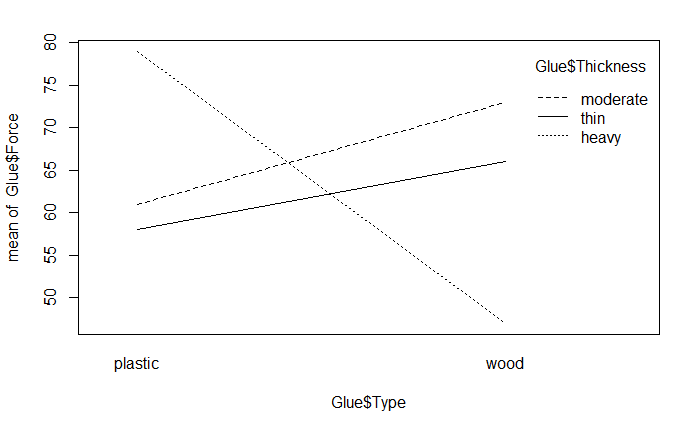

```r
interaction.plot(Glue$Type, Glue$Thickness, Glue$Force)
```

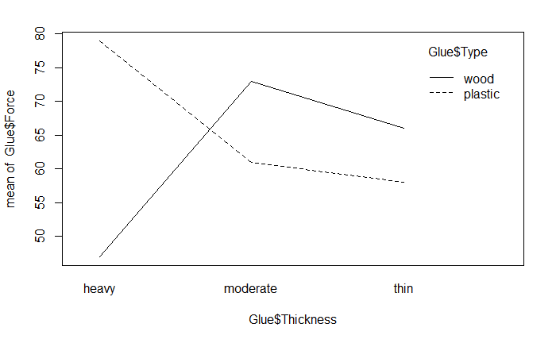

```r
interaction.plot(Glue$Thickness, Glue$Type, Glue$Force)
```